# Practical Machine Learning Project

Stephanie Denis

19 May 2017

## Executive Summary

In this exercise we predicted how well six young health participants performed their strength exercises. They were asked to perform one set of 10 repetitions of the Unilateral Dumbbell Biceps Curl in five different ways, some of which had to be done using proper form, while others were done using improper form. We tested four different prediction models (decision tree, boosting tree, bagging tree and random forest) to determine the model that best predicts the data. We found that the random forest prediction model best predicted the manner in which these exercises were performed.

## Load Data

```r
# Set working directory
setwd("~/Desktop/Rprogramming/8_Practical_Machine_Learning/practical-machine-learning/")

# Download files from URL
if(!file.exists("./data/pml-training.csv")) {
  url.training <- "https://d396qusza40orc.cloudfront.net/predmachlearn/pml-training.csv"
  download.file(url.training, destfile="./data/pml-training.csv")
}

if(!file.exists("./data/pml-testing.csv")) {
  url.testing <- "https://d396qusza40orc.cloudfront.net/predmachlearn/pml-testing.csv"
  download.file(url.testing, destfile="./data/pml-testing.csv")
}

# Load data
pml.training <- read.csv("./data/pml-training.csv", na.strings=c("NA","#DIV/0!",""))
pml.testing <- read.csv("./data/pml-testing.csv", na.strings=c("NA","#DIV/0!",""))

# Load packages
library(knitr); library(caret); library(gbm); library(randomForest);
library(rattle); library(rpart); library(rpart.plot); library(gbm);
library(plyr); library(ipred); library(e1071)

# Check dimensions before cleaning data
dim(pml.training)
```

```
## [1] 19622   160
```

```r
dim(pml.testing)
```

```
## [1]  20 160
```

```r
unique(pml.training$classe)
```

```
## [1] A B C D E
## Levels: A B C D E
```

The training set contains 19,622 observations and 160 variables, while the test set consists of 20 observations and 160 variables. The outcome variable used to predict the manner in which the dumbbell bicep curls are being performed is called `classe` and it contains 5 levels: exactly according to the specification (Class A); throwing the elbows to the front (Class B); lifting the dumbbell only halfway (Class C); lowering the dumbbell only halfway (Class D) and throwing the hips to the front (Class E).

## Data Cleaning

The raw training and test sets needed to be cleaned by removing all missing values in order to run the prediction models.

```r
# Removing predictors that are unnecessary for the analysis
pml.training <- pml.training[, -c(1:7)]
pml.testing <- pml.testing[, -c(1:7)]

# Removing predictors with NAs
pml.training <- pml.training[, colSums(is.na(pml.training))==0]
pml.testing <- pml.testing[, colSums(is.na(pml.testing))==0]

# Check dimensions of training and testing data sets
dim(pml.training)
```

```
## [1] 19622    53
```

```r
dim(pml.testing)
```

```
## [1] 20 53
```

The cleaned training and test sets now contain 53 variables.

## Data Partitioning

In order to proceed with the prediction models, the cleaned training set had to be partitioned in two sets. One set served as the training set which we used to run the prediction model. The other set is used to predict the out-of-sample observations.

```r
# Partitioning clean training data set
inTrain <- createDataPartition(y=pml.training$classe, p=0.70, list=FALSE)
training <- pml.training[inTrain,]
testing <- pml.training[-inTrain,]

# Check dimensions of training and testing data sets
dim(training)
```

```
## [1] 13737    53
```

```r
dim(testing)
```

```
## [1] 5885   53
```

```r
# Number of observations by class
summary(training$classe)
```

```
##    A    B    C    D    E
## 3906 2658 2396 2252 2525
```

Seventy percent (13,737 observations) of the cleaned training set went into a new training set, while 30 percent (5,885 observations) went into a new test set. Each class in the training set is evenly distributed in size, except for Class A, which has more observations.

## Baseline Prediction Model

For our baseline model, we applied a decision tree algorithm using all possible predictors in our data set to predict the manner in which participants performed their exercises. We used the cross-validation method to select the number of predictors and a three fold cross-validation, in place of the default 10 fold, to lower the amount of computing time.

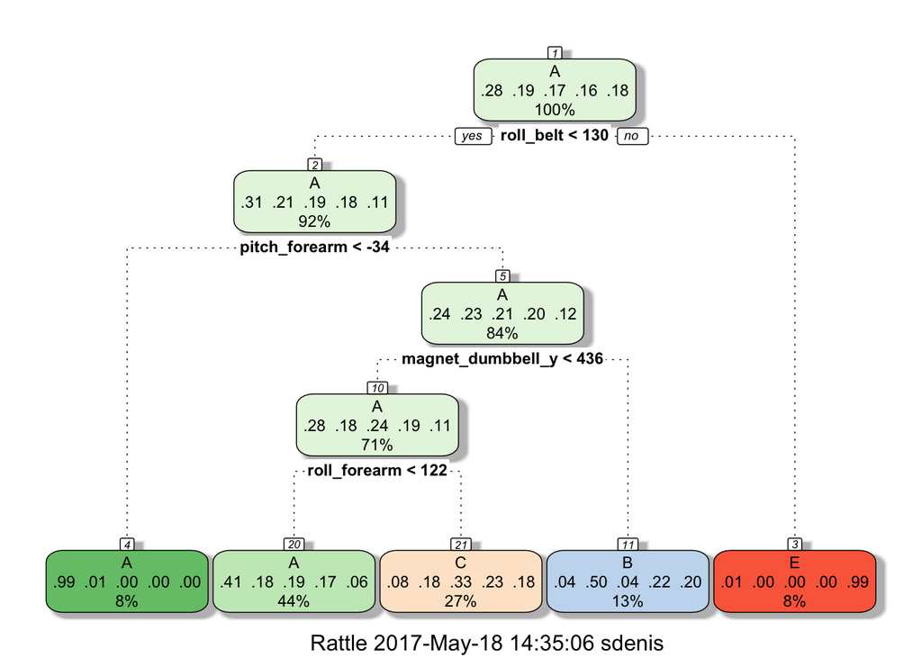

```r
# Set seed for reproducibility
set.seed(123)

# Decision trees
mod_dt <- train(classe ~ ., data=training, method="rpart",
                trControl=trainControl(method="cv", number=3))

# Predict out-of-sample
pred_dt <- predict(mod_dt, testing)

# Plot decision trees
fancyRpartPlot(mod_dt$finalModel)
```

The decision tree shows that `roll_belt`, `pitch_forearm`, `magnet_dumbbell_y` and `roll_forearm` have a higher chance of explaining the manner in which the exercise is performed by participants.

```r
# Confusion matrix
cm_dt <- confusionMatrix(pred_dt, testing$classe)
cm_dt$table
```

```
##           Reference
## Prediction    A    B    C    D    E
##          A 1521  459  474  428  158
##          B   26  406   36  183  144
##          C  124  274  516  353  298
##          D    0    0    0    0    0
##          E    3    0    0    0  482
```

```r
# Accurary rate
accuracy_dt <- round((as.numeric(cm_dt$overall[1]))*100,1)

# Out-of-Sample error rate
oose_dt <- round((1-as.numeric(cm_dt$overall[1]))*100,1)
```

In the table above, each column holds the reference (or actual) data and within each row is the prediction. The diagonal represents instances where our observation correctly predicted the class of the item. We can see here that the decision model predicted poorly the different classes. With an overall accuracy rate of 49.7 percent and an expected out-of-sample error rate of 50.3, we decided to estimate other prediction models.

## Other Prediction Models

```r
# Set seed for reproducibility
set.seed(123)

# Fit and predict models
mod_rf <- train(classe ~ ., data=training, method="rf", importance=TRUE,
               trControl = trainControl(method="cv", number=3))
pred_rf <- predict(mod_rf, testing)

mod_gbm <- train(classe ~ ., data=training, method="gbm", verbose=FALSE,
               trControl = trainControl(method = "cv", number=3))
pred_gbm <- predict(mod_gbm, testing)

mod_bag <- train(classe ~ ., data=training, method="treebag")
pred_bag <- predict(mod_bag, testing)
```

## Choosing Best Model

We predicted each model using the testing set and selected the model with the highest overall accuracy rate.

```r
# Set seed for reproducibility
set.seed(123)

# Confusion matrix
cm_gbm <- confusionMatrix(pred_gbm, testing$classe)
cm_bag <- confusionMatrix(pred_bag, testing$classe)
cm_rf <- confusionMatrix(pred_rf, testing$classe)

# Choosing prediction model with highest overall accuracy
bestMod <- data.frame(Tree=cm_dt$overall[1],
                      Boosting=cm_gbm$overall[1],
                      Bagging=cm_bag$overall[1],
                      RandomForest=cm_rf$overall[1])
# Best model
round(bestMod,3)
```

```
##           Tree Boosting Bagging RandomForest
## Accuracy 0.497    0.967   0.987        0.994
```

We found that among all models tested, the random forest had the highest overall accuracy rate, followed by the bagging tree model, then the boosting tree model.

## Interpreting Best Model

We referred to the table comparing observed and predicted classes as well as to cross-validation plots and the list of variables by importance to interpret the results from our random forest model.

```r
# Accurary rate
accuracy_rf <- round((as.numeric(cm_rf$overall[1]))*100,1)

# Out-of-Sample error rate
oose_rf <- round((1-as.numeric(cm_rf$overall[1]))*100,1)

# Cross-tabulation of observed and predicted classes
mod_rf$finalModel
```

```
##
## Call:
##  randomForest(x = x, y = y, mtry = param$mtry, importance = TRUE)
##                Type of random forest: classification
##                      Number of trees: 500
## No. of variables tried at each split: 2
##
##         OOB estimate of  error rate: 0.65%
## Confusion matrix:
##      A    B    C    D    E  class.error
## A 3904    2    0    0    0 0.0005120328
## B   12 2638    8    0    0 0.0075244545
## C    0   20 2371    5    0 0.0104340568
## D    0    0   32 2218    2 0.0150976909
## E    0    0    3    5 2517 0.0031683168
```

Our random forest model has an overall accuracy rate of 99.4 percent, and an expected out-of-sample error rate of 0.6 percent. Moreover, the diagonal in the cross-tabulation shows that our random forest model does a markedly better job at predicting classes than our decision tree model.

```r
# Summary output
mod_rf
```

```
## Random Forest
##
## 13737 samples
##    52 predictor
##     5 classes: 'A', 'B', 'C', 'D', 'E'
##
## No pre-processing
## Resampling: Cross-Validated (3 fold)
## Summary of sample sizes: 9157, 9160, 9157
## Resampling results across tuning parameters:
##
##   mtry  Accuracy   Kappa
##    2    0.9893717  0.9865547
##   27    0.9884987  0.9854511
##   52    0.9807830  0.9756884
##
## Accuracy was used to select the optimal model using  the largest value.
## The final value used for the model was mtry = 2.
```

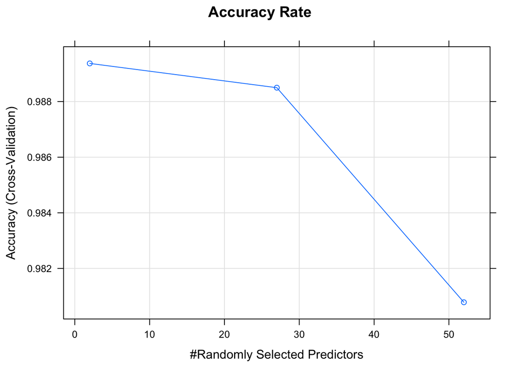

```r
# Cross-validation plots
plot(mod_rf, main="Accuracy Rate")
```

The cross-validation plot shows that the model with 2 randomly selected predictors has the highest overall accuracy rate compared to the model with 27 and 52 randomly selected predictors.

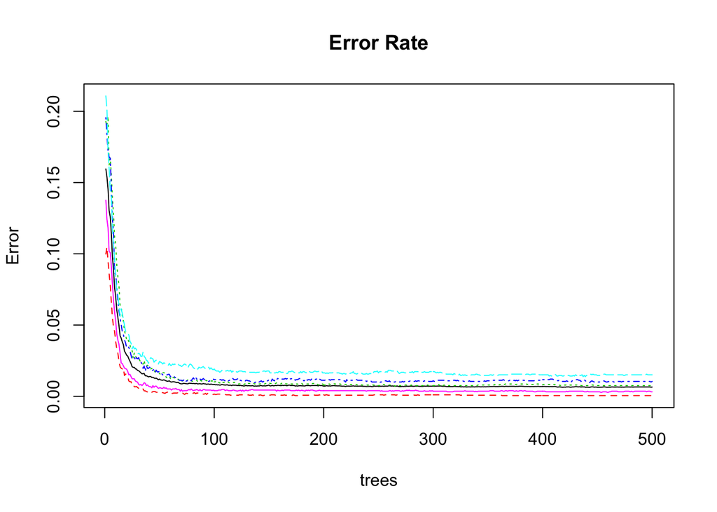

```r
# Cross-validation plots
plot(mod_rf$finalModel, main="Error Rate")
```

The error rate plot shows that it takes 100 trees to stabilize the error estimate.

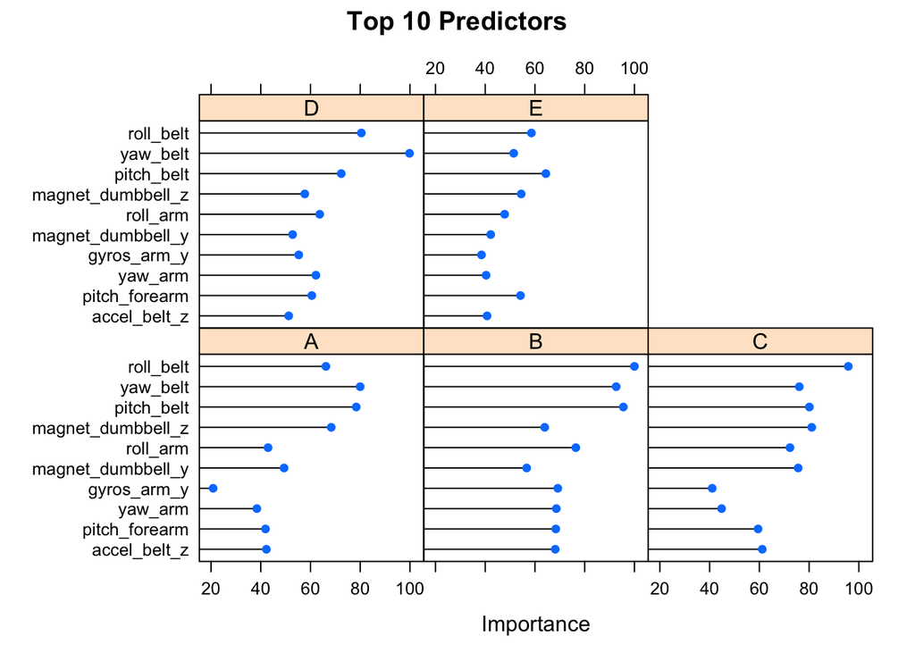

```r
# Variable importance
plot(varImp(mod_rf), top=10, main="Top 10 Predictors")
```

The variables by importance plot shows that `roll_belt`, `pitch_belt` and `yaw_belt` have a higher chance than the other variables of explaining the manner in which the exercise is performed by participants.

## Prediction

We used our random forest model chosen above to predict the original test set with the 20 out-of-sample observations.

```r
# Predict using original testing set
pred <- predict(mod_rf, pml.testing)
pred
```

```
##  [1] B A B A A E D B A A B C B A E E A B B B
## Levels: A B C D E
```

## Conclusion

We predicted how well six young health participants performed one set of 10 repetitions of the Unilateral Dumbbell Biceps Curl. Using a random forest prediction model, we were able to predict the manner in which they performed these exercises with an accuracy rate of 99.4 percent in the out-of-sample set.

## Source Data

Ugulino, W.; Cardador, D.; Vega, K.; Velloso, E.; Milidiu, R.; Fuks, H. Wearable Computing: Accelerometers’ Data Classification of Body Postures and Movements. http://groupware.les.inf.puc-rio.br/har#ixzz4gvEue4LQ